# Bacterias sicotrópicas

Kenneth Roy Cabrera Torres

3 de febrero de 2016

## Supresión del crecimiento bacterial en carnes almacenadas

Ejemplo del libro: Kuehl, Robert O. Diseño de Experimentos. Principios estadísticos para el diseño y análisis de investigaciones. 2da Edición. Thomson Learning. 2001

La vida de anaquel de las carnes almacenadas es el tiempo que un corte previamente empacado es sano, nutritivo y vendible. Un paquete normal expuesto al aire ambiental tiene una vida aproximada de 48 horas, después de las cuales la carne comienza a deteriorarse por contaminación de microbios, degradación del color y encogimiento. El empaque al vacío es efectivo para suprimir el desarrollo de microbios; sin embargo, continúan siendo un problema los otros aspectos.

Algunos estudios recientes sugieren las atmósferas controladas de gas, como altemativa a los empaques actuales. Dos atmósferas que prometen combinar la capacidad de suprimir el desarrollo de microbios con la conservación de las cualidades de la carne son: 1) dióxido de carbono puro (CO,), y 2) mezclas de monóxido de carbono (CO), oxígeno (O,) y nitrógeno (N).

### Hipótesis de investigación:

Con base en esta nueva información, el investigador plantea la hipótesis de que alguna forma de atmósfera controlada proporcionará un entorno más efectivo de empaque para el almacenamiento de carne.

### Diseño del tratamiento:

El diseño del tratamiento desarrollado por el investigador para evaluar la hipótesis incluyó empaques con: 1) aire del ambiente con un empaque comercial de plástico; 2) al vacío; 3) una mezcla de gases con 1% CO, 40% O2 y 59% N y 4)100% CO2. Los empaques con el aire del ambiente y al vacío sirven como tratamientos de control, ya que ambos son estándares con cuya efectividad se puede comparar la de los nuevos empaques.

Diseño del experimento: Se usó un diseño totalmente aleatorizado para el experimento. A cada conjunto de condiciones de empaque se le asignaron al azar 3 cortes del mismo tamaño (75 g). Cada corte se empacó por separado en las condiciones asignadas.

En este ejemplo, se evalúa la efectividad de cada tratamiento para suprimir el desarrollo bacterial. Después de 9 días de almacenamiento a 4°C en una instalación normal, se midió el número de bacterias sicotrópicas en la carne. Las bacterias sicotrópicas se encuentran en la superficie de la carne y se asocian con la carne deteriorada.

### Resultados

Los resultados se muestran en la siguiente tabla:

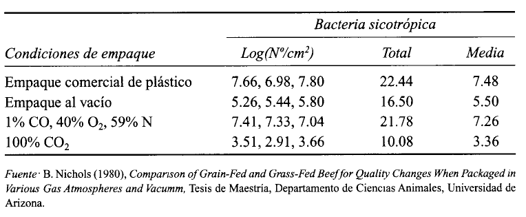

## Lectura de la base de datos

```r
bacterias <- read.csv2("Bacterias_en_carne.csv")
```

## Despligue de la base de datos

```r
bacterias
```

```
##     Empaque replica logNcm2
## 1  plástico       1    7.66
## 2     vacío       1    5.26
## 3   C0_O2_N       1    7.41
## 4       CO2       2    3.51
## 5  plástico       2    6.98
## 6     vacío       2    5.44
## 7   C0_O2_N       2    7.33
## 8       CO2       3    2.91
## 9  plástico       3    7.80
## 10    vacío       3    5.80
## 11  C0_O2_N       3    7.04
## 12      CO2       3    3.66
```

## Resumen estadístico

```r
summary(bacterias)
```

```
##      Empaque     replica         logNcm2
##  C0_O2_N :3   Min.   :1.000   Min.   :2.91
##  CO2     :3   1st Qu.:1.750   1st Qu.:4.86
##  plástico:3   Median :2.000   Median :6.39
##  vacío   :3   Mean   :2.167   Mean   :5.90
##               3rd Qu.:3.000   3rd Qu.:7.35
##               Max.   :3.000   Max.   :7.80
```

```r
sd(bacterias$logNcm2)
```

```
## [1] 1.752909
```

## Resumen estadístico por tipo de empaque

```r
with(bacterias, tapply(logNcm2, Empaque, summary))
```

```
## $C0_O2_N
##    Min. 1st Qu.  Median    Mean 3rd Qu.    Max.
##   7.040   7.185   7.330   7.260   7.370   7.410
##
## $CO2
##    Min. 1st Qu.  Median    Mean 3rd Qu.    Max.
##   2.910   3.210   3.510   3.360   3.585   3.660
##
## $plástico
##    Min. 1st Qu.  Median    Mean 3rd Qu.    Max.
##    6.98    7.32    7.66    7.48    7.73    7.80
##
## $vacío
##    Min. 1st Qu.  Median    Mean 3rd Qu.    Max.
##    5.26    5.35    5.44    5.50    5.62    5.80
```

```r
with(bacterias, tapply(logNcm2, Empaque, sd))
```

```
##   C0_O2_N       CO2  plástico     vacío
## 0.1946792 0.3968627 0.4386342 0.2749545
```

## Gráfica simple

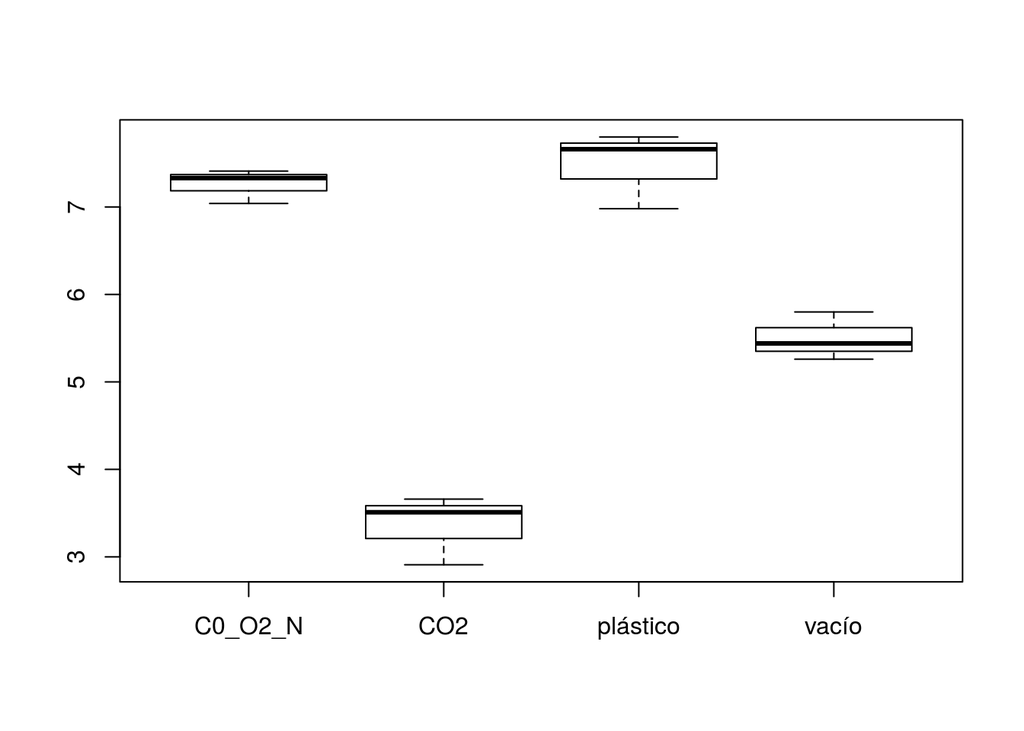

```r
with(bacterias, plot(Empaque, logNcm2))
```

## Gráfica mejorada I

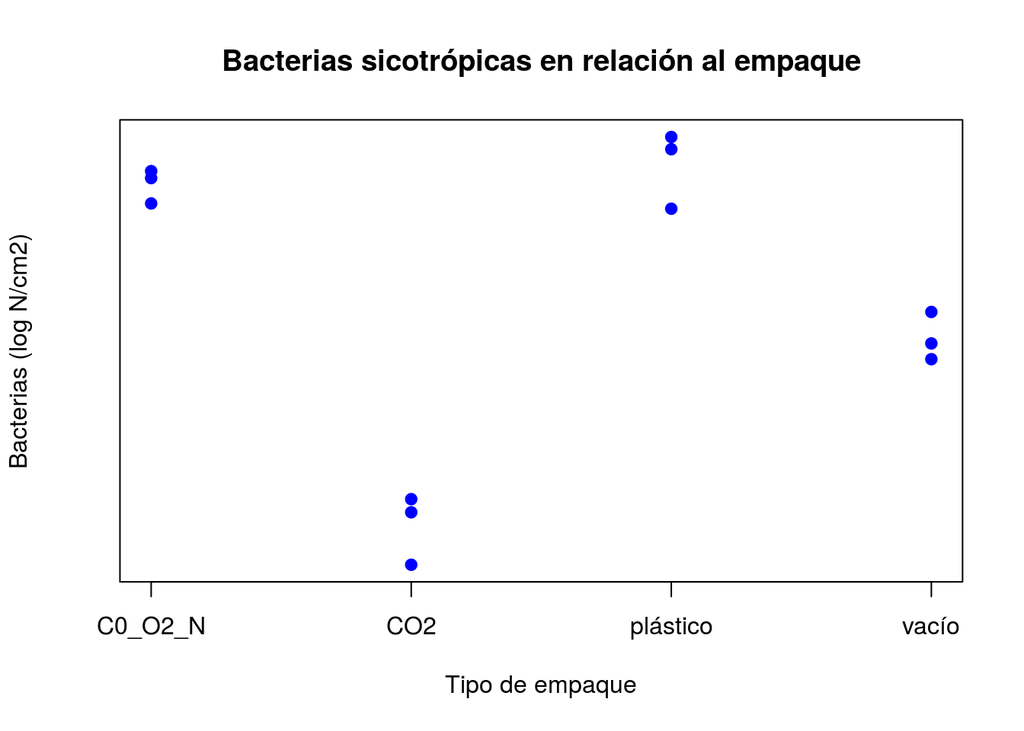

```r
with(bacterias, plot(as.integer(Empaque), logNcm2, axes = FALSE,
                     pch  = 19, col = "blue",
                     main = "Bacterias sicotrópicas en relación al empaque",
                     ylab = "Bacterias (log N/cm2)",
                     xlab = "Tipo de empaque"))
axis(1, at = 1:4, labels = levels(bacterias$Empaque), las = 1)
box()
```

## Gráficas mejorada II

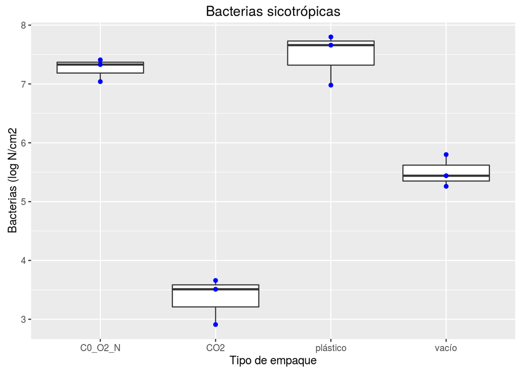

```r
require(ggplot2)
ggplot(bacterias, aes(Empaque, logNcm2)) +
  geom_boxplot() +
  geom_point(col = "blue") +
  ylab("Bacterias (log N/cm2") +
  xlab("Tipo de empaque") +
  ggtitle("Bacterias sicotrópicas")
```